# Analisis de bd Call Center

Francisco Flor

2025-05-13

**📁 Carga de Datos**

```r
head(Call.Center.Data, 10)
```

```
##    index incoming_calls answered_calls answer_rate abandoned_calls
## 1      1            217            204      94.01%              13
## 2      2            200            182      91.00%              18
## 3      3            216            198      91.67%              18
## 4      4            155            145      93.55%              10
## 5      5             37             37     100.00%               0
## 6      6            315            304      96.51%              11
## 7      7            252            244      96.83%               8
## 8      8            213            205      96.24%               8
## 9      9            219            200      91.32%              19
## 10    10            371            348      93.80%              23
##    answer_speed_avg talk_duration_avg waiting_time_avg service_level_20_seconds
## 1           0:00:17           0:02:14          0:02:45                   76.28%
## 2           0:00:20           0:02:22          0:06:55                   72.73%
## 3           0:00:18           0:02:38          0:03:50                   74.30%
## 4           0:00:15           0:02:29          0:03:12                   79.61%
## 5           0:00:03           0:02:06          0:00:35                   97.30%
## 6           0:00:18           0:01:35          0:02:37                   77.17%
## 7           0:00:13           0:01:50          0:02:02                   82.00%
## 8           0:00:10           0:02:10          0:03:22                   88.10%
## 9           0:00:15           0:02:18          0:06:12                   79.45%
## 10          0:00:19           0:01:40          0:03:29                   73.63%
```

```r
glimpse(Call.Center.Data)
```

```
## Rows: 1,251
## Columns: 9
## $ index                    <int> 1, 2, 3, 4, 5, 6, 7, 8, 9, 10, 11, 12, 13, 14…
## $ incoming_calls           <int> 217, 200, 216, 155, 37, 315, 252, 213, 219, 3…
## $ answered_calls           <int> 204, 182, 198, 145, 37, 304, 244, 205, 200, 3…
## $ answer_rate              <chr> "94.01%", "91.00%", "91.67%", "93.55%", "100.…
## $ abandoned_calls          <int> 13, 18, 18, 10, 0, 11, 8, 8, 19, 23, 2, 0, 9,…
## $ answer_speed_avg         <chr> "0:00:17", "0:00:20", "0:00:18", "0:00:15", "…
## $ talk_duration_avg        <chr> "0:02:14", "0:02:22", "0:02:38", "0:02:29", "…
## $ waiting_time_avg         <chr> "0:02:45", "0:06:55", "0:03:50", "0:03:12", "…
## $ service_level_20_seconds <chr> "76.28%", "72.73%", "74.30%", "79.61%", "97.3…
```

```r
summary(Call.Center.Data)
```

```
##      index        incoming_calls   answered_calls  answer_rate
##  Min.   :   1.0   Min.   :   5.0   Min.   :  5.0   Length:1251
##  1st Qu.: 313.5   1st Qu.: 123.0   1st Qu.:114.0   Class :character
##  Median : 626.0   Median : 177.0   Median :166.0   Mode  :character
##  Mean   : 626.0   Mean   : 198.5   Mean   :176.8
##  3rd Qu.: 938.5   3rd Qu.: 233.0   3rd Qu.:214.5
##  Max.   :1251.0   Max.   :1575.0   Max.   :909.0
##  abandoned_calls  answer_speed_avg   talk_duration_avg  waiting_time_avg
##  Min.   :  0.00   Length:1251        Length:1251        Length:1251
##  1st Qu.:  3.00   Class :character   Class :character   Class :character
##  Median :  8.00   Mode  :character   Mode  :character   Mode  :character
##  Mean   : 21.69
##  3rd Qu.: 16.00
##  Max.   :704.00
##  service_level_20_seconds
##  Length:1251
##  Class :character
##  Mode  :character
##
##
##
```

```r
# 3. Convertir columnas clave a numéricas (si están como texto)

# Función para limpiar columnas numéricas con problemas
limpiar_numero <- function(x) {
  x <- gsub(",", ".", x)      # Reemplaza coma por punto (para decimales)
  x <- gsub("%", "", x)       # Quita porcentaje si lo hubiera
  x <- gsub("-", "0", x)      # Reemplaza guiones por 0
  x <- gsub("[^0-9\\.]", "", x) # Quita cualquier cosa que no sea número o punto
  as.numeric(x)               # Convierte a número
}

# Aplicar limpieza a columnas clave

Data <- Call.Center.Data %>%
  mutate(
    waiting_time_avg = limpiar_numero(waiting_time_avg),
    answer_speed_avg = limpiar_numero(answer_speed_avg),
    service_level_20_seconds = limpiar_numero(service_level_20_seconds) / 100,  # Si viene en porcentaje
    answer_rate = limpiar_numero(answer_rate) / 100
  )
```

📝 Resumen Ejecutivo

Este reporte analiza metricas clave de desempeño en un contact center, donde se intenta evaluar:

-Nivel de servicio

-Tiempo de espera

-Llamadas abandonadas

-Relación entre carga de llamadas y atención

**📊 Métricas Generales**

```r
# Tasa de respuesta promedio
tasa_respuesta_prom <- mean(Data$answer_rate, na.rm = TRUE)

# Nivel de servicio promedio
nivel_servicio_prom <- mean(Data$service_level_20_seconds, na.rm = TRUE)

# Velocidad promedio de respuesta
velocidad_resp_prom <- mean(Data$answer_speed_avg, na.rm = TRUE)

# Tiempo promedio de espera
tiempo_espera_prom <- mean(Data$waiting_time_avg, na.rm = TRUE)

# Mostrar resultados
cat("📊 Tasa de Respuesta Promedio: ", round(tasa_respuesta_prom * 100, 2), "%\n")
```

```
## 📊 Tasa de Respuesta Promedio:  92.69 %
```

```r
cat("✅ Nivel de Servicio Promedio: ", round(nivel_servicio_prom * 100, 2), "%\n")
```

```
## ✅ Nivel de Servicio Promedio:  70.87 %
```

```r
cat("⏱️ Velocidad Promedio de Respuesta: ", round(velocidad_resp_prom, 2), "segundos\n")
```

```
## ⏱️ Velocidad Promedio de Respuesta:  27.3 segundos
```

```r
cat("⏳ Tiempo Promedio de Espera: ", round(tiempo_espera_prom, 2), "segundos\n")
```

```
## ⏳ Tiempo Promedio de Espera:  366.16 segundos
```

**📊 Analisis de las metricas generales.**

Tasa de Respuesta Promedio: 92.69% , se puede indicar que es muy buena, y que se estan contestando la mayoria de las llamadas.

Nivel de Servicio Promedio (20 segundos): 70.87%.

Velocidad Promedio de Respuesta: 27.3 segundos (mal, encima del objetivo de la bd -20s-)

**📉 Analisis Grafico**

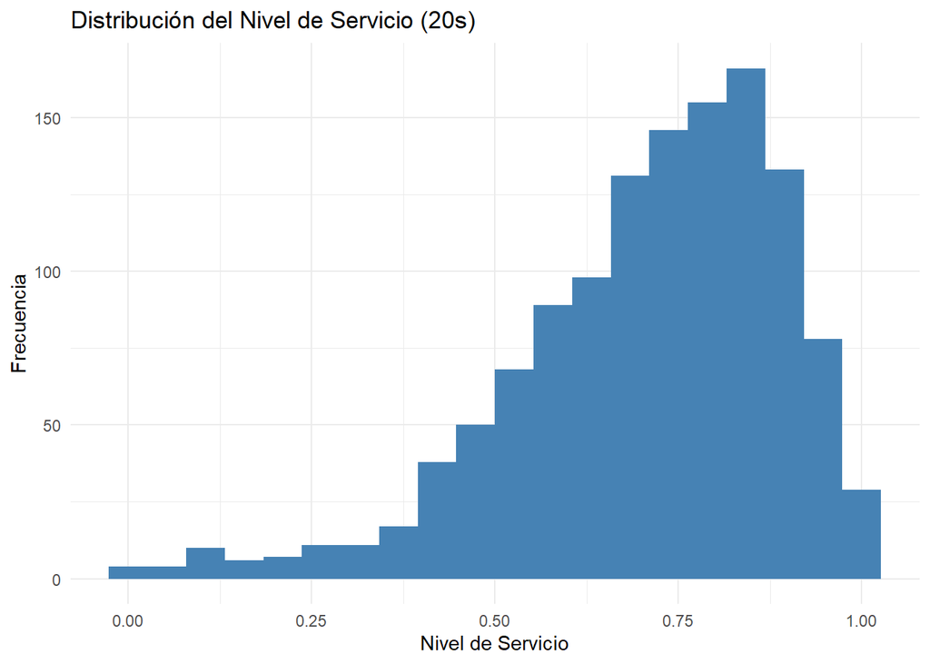

```r
# Histograma del nivel de servicio
ggplot(Data, aes(x = service_level_20_seconds)) +
  geom_histogram(fill = "steelblue", bins = 20) +
  labs(title = "Distribución del Nivel de Servicio (20s)", x = "Nivel de Servicio", y = "Frecuencia") +
  theme_minimal()
```

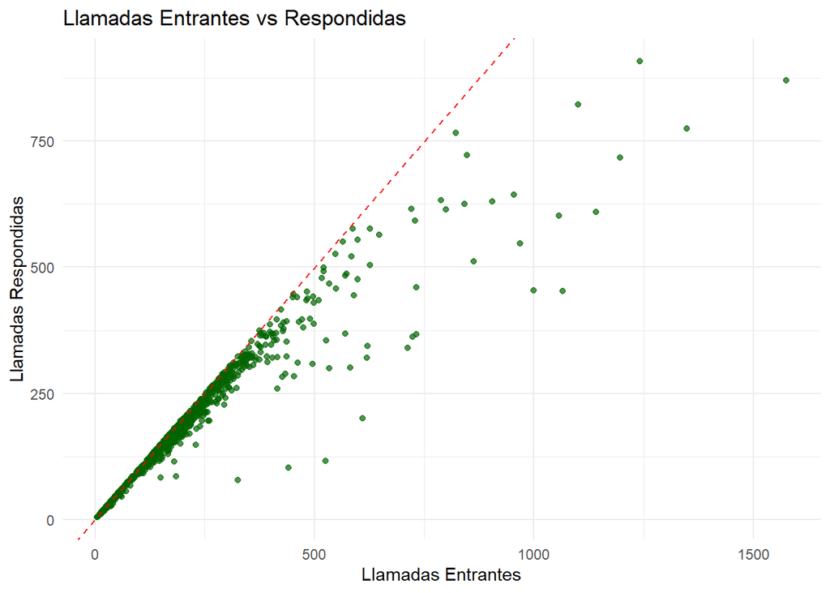

```r
# Relación entre llamadas entrantes y respondidas
ggplot(Data, aes(x = incoming_calls, y = answered_calls)) +
  geom_point(color = "darkgreen", alpha = 0.7) +  # puntos de dispersión
  geom_abline(slope = 1, intercept = 0, linetype = "dashed", color = "red") +  # línea y = x
  labs(
    title = "Llamadas Entrantes vs Respondidas",
    x = "Llamadas Entrantes",
    y = "Llamadas Respondidas"
  ) +
  theme_minimal()
```

**Conclusiones analisis grafico.**

📊 Gráfico: Distribución del Nivel de Servicio (20s)

La mayoría de las observaciones se concentran en niveles de servicio superiores al 70%, lo cual es un indicio de un desempeño bueno. Sin embargo, tambien se observa una frecuencia significativa de registros con niveles por debajo del 50%, lo que sugiere que existen momentos donde no se alcanzan los estándares deseados.

Una posibilidad para analizar sería identificar los registros con nivel de servicio inferior al 50% para entender las causas de bajo rendimiento. Sin embargo, debido a la ausencia de variables como fecha, hora o identificadores de agentes, no es posible extraer conclusiones causales o temporales más profundas.

📞 Gráfico: Llamadas Entrantes vs Respondidas

El gráfico evidencia una brecha entre las llamadas entrantes y las llamadas efectivamente respondidas, lo cual sugiere que la demanda no siempre puede ser atendida completamente. Esto puede estar relacionado con una capacidad operativa limitada en ciertos momentos o con problemas de eficiencia en la atención.

Nuevamente, la falta de información temporal o por agente limita la posibilidad de realizar un análisis más detallado para identificar patrones específicos o áreas de mejora concretas.

**📈 Analisis de Correlaciones**

```r
# 1. Correlacion entre Tiempo de Espera y Llamadas Abandonadas
cor_abandono_espera <- cor(Data$waiting_time_avg, Data$abandoned_calls, use = "complete.obs")
cat("📈 Correlación entre Tiempo de Espera y Llamadas Abandonadas: ", round(cor_abandono_espera, 2), "\n")
```

```
## 📈 Correlación entre Tiempo de Espera y Llamadas Abandonadas:  0.72
```

```r
# 2. Correlacion entre Llamadas Entrantes y Nivel de Servicio
cor_llamadas_servicio <- cor(Data$incoming_calls, Data$service_level_20_seconds, use = "complete.obs")
cat("🔄 Correlación entre Llamadas Entrantes y Nivel de Servicio: ", round(cor_llamadas_servicio, 2), "\n")
```

```
## 🔄 Correlación entre Llamadas Entrantes y Nivel de Servicio:  -0.49
```

**📊 Interpretación de correlaciones:**

📈 Correlación Tiempo de Espera vs Llamadas Abandonadas: 0.72

Es una correlación fuerte y positiva.

Esto significa que cuando el tiempo de espera sube, también suben las llamadas que la gente abandona.

La espera está haciendo que los clientes cuelguen antes de ser atendidos.

🔄 Correlación Llamadas Entrantes vs Nivel de Servicio: -0.49

Es una correlación negativa moderada.

Esto significa que cuando entran más llamadas, el nivel de servicio baja.

No es extremo, pero sí indica que la carga está afectando el desempeño.

**📉 Visualizacion de Metricas Clave**

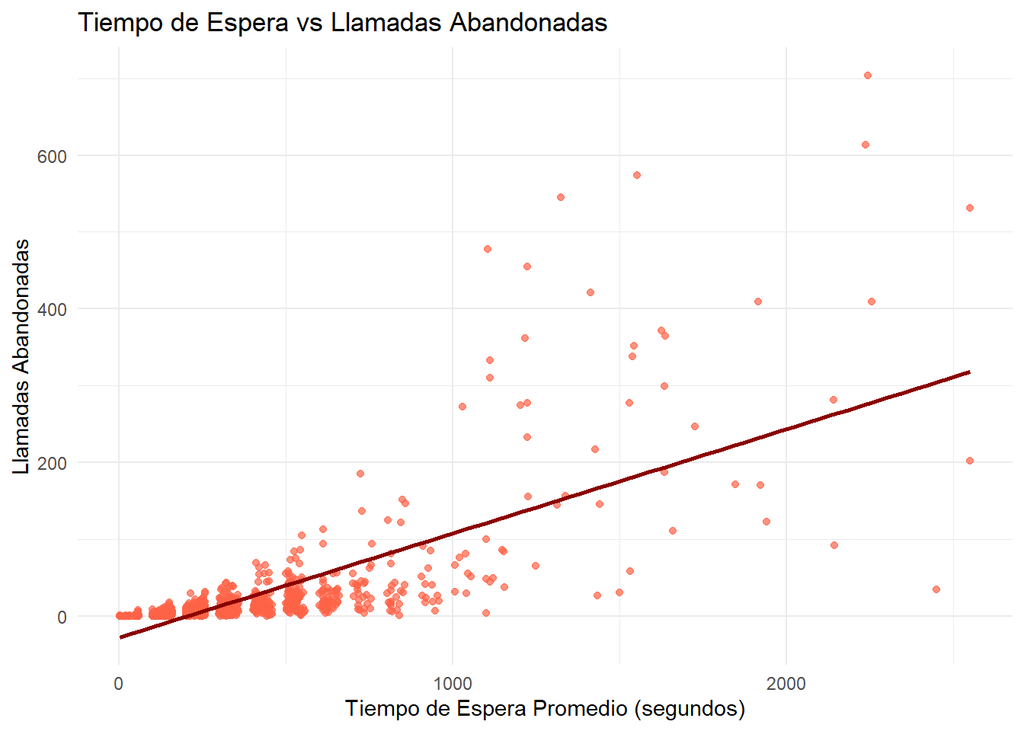

```r
# 3. Grafico: Tiempo de Espera vs Llamadas Abandonadas
ggplot(Data, aes(x = waiting_time_avg, y = abandoned_calls)) +
  geom_point(color = "tomato", alpha = 0.7) +
  geom_smooth(method = "lm", se = FALSE, color = "darkred") +
  labs(title = "Tiempo de Espera vs Llamadas Abandonadas",
       x = "Tiempo de Espera Promedio (segundos)",
       y = "Llamadas Abandonadas") +
  theme_minimal()
```

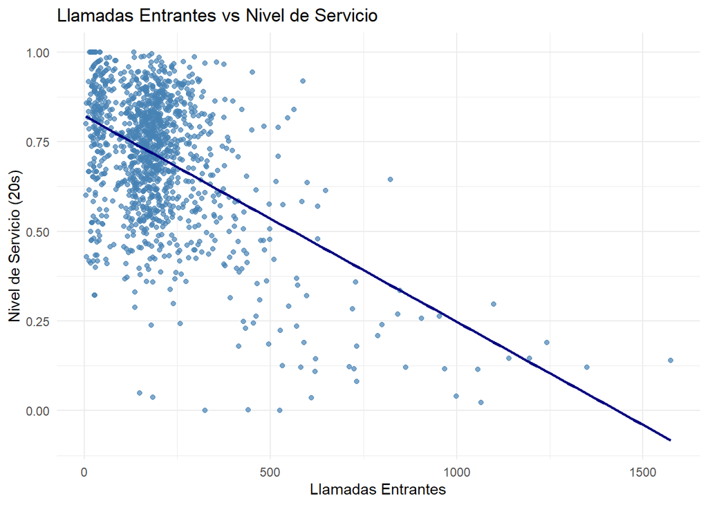

```r
# 4. Grafico: Llamadas Entrantes vs Nivel de Servicio
ggplot(Data, aes(x = incoming_calls, y = service_level_20_seconds)) +
  geom_point(color = "steelblue", alpha = 0.7) +
  geom_smooth(method = "lm", se = FALSE, color = "navy") +
  labs(title = "Llamadas Entrantes vs Nivel de Servicio",
       x = "Llamadas Entrantes",
       y = "Nivel de Servicio (20s)") +
  theme_minimal()
```

**Conclusiones de los Gráficos Operativos**

**Gráfico: Tiempo de Espera vs Llamadas Abandonadas** Se observa una clara relación positiva: a medida que aumenta el tiempo de espera, también lo hace el número de llamadas abandonadas. Esto puede indicar deficiencias en la atención, tiempos de respuesta excesivos o falta de personal suficiente en ciertos momentos.

**Gráfico: Llamadas Entrantes vs Nivel de Servicio** El gráfico muestra una relación inversa entre el número de llamadas entrantes y el nivel de servicio. Aunque no se cuenta con variables temporales para identificar momentos específicos del día, se observa que en registros con mayor volumen de llamadas, el nivel de servicio disminuye. Esto sugiere una posible limitación estructural en la capacidad de respuesta del centro de llamadas ante altos volúmenes, lo cual podría afectar la calidad de atención si no se ajustan los recursos disponibles.

**🚩 Registros Críticos y Buenos**

```r
# Definir umbrales
umbral_espera_alta <- quantile(Data$waiting_time_avg, 0.75, na.rm = TRUE)  # top 25% en espera
umbral_servicio_bajo <- quantile(Data$service_level_20_seconds, 0.25, na.rm = TRUE)  # bottom 25% en nivel de servicio

umbral_espera_baja <- quantile(Data$waiting_time_avg, 0.25, na.rm = TRUE)  # bottom 25% en espera
umbral_servicio_alto <- quantile(Data$service_level_20_seconds, 0.75, na.rm = TRUE)  # top 25% en nivel de servicio

# Detectar registros criticos
registros_criticos <- Data %>%
  filter(waiting_time_avg >= umbral_espera_alta & service_level_20_seconds <= umbral_servicio_bajo)

cat("🚩 Registros Críticos Detectados: ", nrow(registros_criticos), "\n")
```

```
## 🚩 Registros Críticos Detectados:  185
```

```r
head(registros_criticos)
```

```
##   index incoming_calls answered_calls answer_rate abandoned_calls
## 1    37            218            189      0.8670              29
## 2   233            169            137      0.8107              32
## 3   234             61             45      0.7377              16
## 4   235            167            136      0.8144              31
## 5   237            229            148      0.6463              81
## 6   281            346            305      0.8815              41
##   answer_speed_avg talk_duration_avg waiting_time_avg service_level_20_seconds
## 1               32           0:02:37              804                   0.5741
## 2               38           0:02:24              530                   0.4036
## 3               32           0:02:49              530                   0.4098
## 4               42           0:02:36              528                   0.3598
## 5               36           0:02:48             1039                   0.4318
## 6               45           0:01:57              507                   0.4503
```

```r
# Detectar registros buenos
registros_buenos <- Data %>%
  filter(waiting_time_avg <= umbral_espera_baja & service_level_20_seconds >= umbral_servicio_alto)

cat("✅ Registros Buenos Detectados: ", nrow(registros_buenos), "\n")
```

```
## ✅ Registros Buenos Detectados:  198
```

```r
head(registros_buenos)
```

```
##   index incoming_calls answered_calls answer_rate abandoned_calls
## 1     5             37             37      1.0000               0
## 2    12             32             32      1.0000               0
## 3    19             45             44      0.9778               1
## 4    26             58             57      0.9828               1
## 5    33             57             55      0.9649               2
## 6    40             52             52      1.0000               0
##   answer_speed_avg talk_duration_avg waiting_time_avg service_level_20_seconds
## 1                3           0:02:06               35                   0.9730
## 2                2           0:02:03                3                   1.0000
## 3                2           0:02:04               55                   0.9778
## 4                4           0:02:26               58                   0.9483
## 5                6           0:02:03              150                   0.9123
## 6                9           0:02:16               52                   0.9423
```

**Conclusiones y Recomendaciones**

**🔹 Desempeño Aceptable pero no Óptimo**

La mayoría de los indicadores muestran un rendimiento razonable. Sin embargo, el análisis del nivel de servicio indica que, aunque gran parte de los registros está por encima del 70%, aún existe una proporción significativa por debajo del 50%, lo que sugiere inconsistencias operativas.

**🔹 Problemas de Capacidad de Respuesta**

Se evidenció que no todas las llamadas entrantes están siendo respondidas.

**🔹 Impacto del Tiempo de Espera en la Satisfacción del Cliente**

El tiempo promedio de espera está claramente relacionado con el abandono de llamadas. Mientras mayor sea la espera, más usuarios cuelgan antes de ser atendidos, lo cual representa una pérdida directa de oportunidad de atención.

**🔹 Limitaciones del Análisis**

La ausencia de variables temporales (como fecha, hora o turno) y de identificación del agente limita el análisis en profundidad. No se puede determinar en qué momentos ni con qué personal se presentan los mayores problemas, lo que restringe la toma de decisiones más dirigidas.

**🔹 Recomendaciones**

- Identificar registros con nivel de servicio < 0.5 y evaluar sus características particulares.
- Implementar sistemas de monitoreo en tiempo real para ajustar la capacidad de respuesta en momentos críticos.
- Considerar una recolección de datos más detallada, incluyendo hora, fecha, agente y canal de contacto, para futuros análisis más precisos.